# LikertMakeR vignette

Hume Winzar

April 2025

```r
library(LikertMakeR)
```

[figure not shown]

**LikertMakeR** [(Winzar, 2022)](https://cran.r-project.org/package=LikertMakeR) lets you create synthetic Likert-scale, or related rating-scale, data.  
Set the mean, standard deviation, and correlations, and the package generates data matching those properties. It can also rearrange existing data columns to achieve a desired correlation structure or generate data based on *Cronbach’s Alpha*, *factor correlations* or other summary statistics.

## Purpose

The package should be useful for teaching in the Social Sciences, and for scholars who wish to “replicate” or “reverse engineer” rating-scale data for further analysis and visualisation when only summary statistics have been reported.

## Motivation

I was prompted to write the functions in *LikertMakeR* after reviewing too many journal article submissions where authors presented questionnaire results with only means and standard deviations (often only the means), with no apparent understanding of scale distributions, and their impact on scale properties.

Hopefully, this tool will help researchers, teachers & students, and other reviewers, to better think about rating-scale distributions, and the effects of variance, scale boundaries, and number of items in a scale. Researchers can also use *LikertMakeR* to prepare analyses ahead of a formal survey.

## Rating scale properties

A Likert scale is the mean, or sum, of several ordinal rating scales. Typically, they are bipolar (usually “agree-disagree”) responses to propositions that are determined to be moderately-to-highly correlated and that capture some facet of a theoretical construct.

Rating scales, such as Likert scales, are not continuous or unbounded.

For example, a 5-point Likert scale that is constructed with, say, five items (questions) will have a summed range of between 5 (all rated ‘1’) and 25 (all rated ‘5’) with all integers in between, and the mean range will be ‘1’ to ‘5’ with intervals of 1/5=0.20. A 7-point Likert scale constructed from eight items will have a summed range between 8 (all rated ‘1’) and 56 (all rated ‘7’) with all integers in between, and the mean range will be ‘1’ to ‘7’ with intervals of 1/8=0.125.

Technically, because they are bounded and not continuous, parametric statistics, such as mean, standard deviation, and correlation, should not be applied to summated rating scales. In practice, however, parametric statistics are commonly used in the social sciences because:

1. they are in common usage and easily understood,
2. results and conclusions drawn from technically-correct non-parametric statistics are *(almost)* always the same as for parametric statistics for such data.  
   For example, [D’Alessandro *et al.* (2020)](https://cengage.com.au/sem121/marketing-research-5th-edition-dalessandro-babin-zikmund) argue that a summated scale, made with multiple items, “approaches” an interval scale measure. This implies that parametric statistics are acceptable.

Rating-scale boundaries define minima and maxima for any scale values. If the mean is close to one boundary then data points will gather more closely to that boundary.  
If the mean is not in the middle of a scale, then the data will be always skewed, as shown in the following plots.

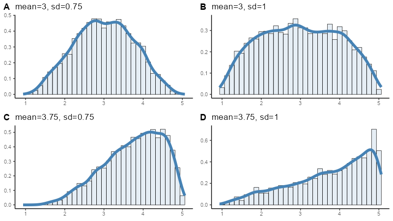

Off-centre means always give skewed distribution in bounded rating scales

## *LikertMakeR* functions

- *lfast()* generate a vector of values with predefined mean and standard deviation.
- *lcor()* takes a dataframe of rating-scale values and rearranges the values in each column so that the columns are correlated to match a predefined correlation matrix.
- *makeCorrAlpha* constructs a random correlation matrix of given dimensions from a predefined *Cronbach’s Alpha*.
- *makeCorrLoadings* constructs a random correlation matrix from a given *factor loadings* matrix, and *factor-correlations* matrix.
- *makeItems()* is a wrapper function for *lfast()* and *lcor()* to generate synthetic rating-scale data with predefined first and second moments and a predefined correlation matrix.
- *makeItemsScale()* generates a random dataframe of scale items based on a predefined summated scale with a desired Cronbach’s Alpha.
- *makePaired()* generates a dataframe of two correlated columns based on summary data from a paired-sample t-test.
- *correlateScales()* creates a dataframe of correlated summated scales as one might find in completed survey questionnaire and possibly used in a Structural Equation model.
- Helper Functions
  - *alpha()* calculates Cronbach’s Alpha from a given correlation matrix or a given dataframe.
  - *eigenvalues()* calculates eigenvalues of a correlation matrix, reports on positive-definite status of the matrix and, optionally, displays a scree plot to visualise the eigenvalues.

# Using *LikertMakeR*

## Download and Install *LikertMakeR*

### from *CRAN*

````
> ```
>
> install.packages("LikertMakeR")
> library(LikertMakeR)
>
> ```
````

### development version from *GitHub*.

````
> ```
>
> library(devtools)
> install_github("WinzarH/LikertMakeR")
> library(LikertMakeR)
>
> ```
````

## Generate synthetic rating-scale data

### *lfast()*

- *lfast()* applies a simple evolutionary algorithm which draws repeated random samples from a scaled *Beta* distribution. It produces a vector of values with mean and standard deviation typically correct to two decimal places.

To synthesise a rating scale with *lfast()*, the user must input the following parameters:

- *n*: sample size
- *mean*: desired mean
- *sd*: desired standard deviation
- *lowerbound*: desired lower bound
- *upperbound*: desired upper bound
- *items*: number of items making the scale - default = 1

An earlier version of *LikertMakeR* had a function, *lexact()*, which was slow and no more accurate than the latest version of *lfast()*. So, *lexact()* is now deprecated.

#### *lfast()* example

##### a four-item, five-point Likert scale

```r
nItems <- 4
mean <- 2.5
sd <- 0.75

x1 <- lfast(
  n = 512,
  mean = mean,
  sd = sd,
  lowerbound = 1,
  upperbound = 5,
  items = nItems
)
```

```
#> best solution in 72 iterations
```

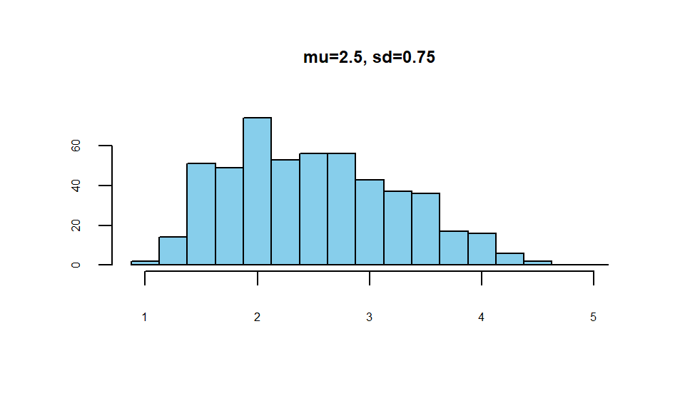

Example: 4-item, 1-5 Likert scale

##### an 11-point likelihood-of-purchase scale

###### *lfast()*

```r
x2 <- lfast(256, 3, 2.5, 0, 10)
```

```
#> best solution in 248 iterations
```

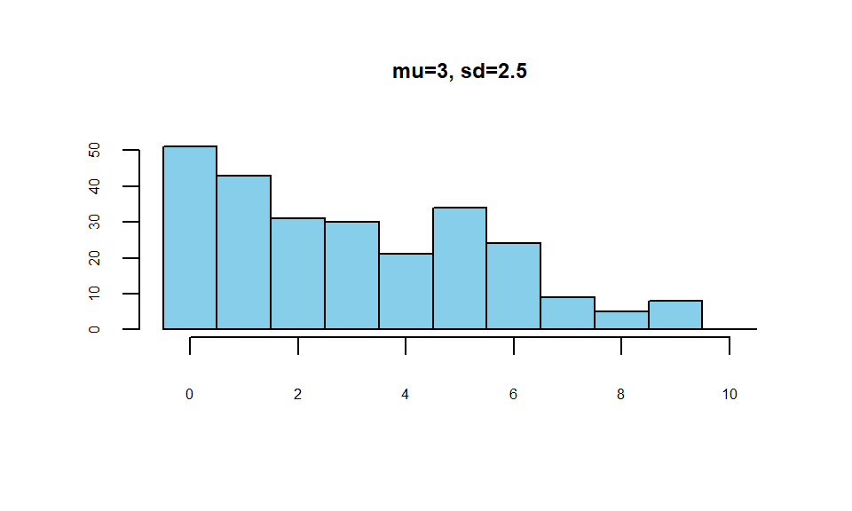

Example: likelihood-of-purchase scale

## Correlating rating scales

The function, *lcor()*, rearranges the values in the columns of a data-set so that they are correlated at a specified level. It does not change the values - it swaps their positions within each column so that univariate statistics do not change, but their correlations with other vectors do.

### *lcor()*

*lcor()* systematically selects pairs of values in a column and swaps their places, and checks to see if this swap improves the correlation matrix. If the revised dataframe produces a correlation matrix closer to the target correlation matrix, then the swap is retained. Otherwise, the values are returned to their original places. This process is iterated across each column.

To create the desired correlated data, the user must define the following parameters:

- *data*: a starter data set of rating-scales. Number of columns must match the dimensions of the *target* correlation matrix.
- *target*: the target correlation matrix.

### *lcor()* example

Let’s generate some data: three 5-point Likert scales, each with five items.

```r
## generate uncorrelated synthetic data
n <- 128
lowerbound <- 1
upperbound <- 5
items <- 5

mydat3 <- data.frame(
  x1 = lfast(n, 2.5, 0.75, lowerbound, upperbound, items),
  x2 = lfast(n, 3.0, 1.50, lowerbound, upperbound, items),
  x3 = lfast(n, 3.5, 1.00, lowerbound, upperbound, items)
)
```

```
#> best solution in 143 iterations
#> best solution in 769 iterations
#> best solution in 332 iterations
```

The first six observations from this dataframe are:

```
#>    x1  x2  x3
#> 1 1.4 1.0 2.4
#> 2 3.0 4.4 3.2
#> 3 1.4 4.8 4.2
#> 4 2.0 1.8 4.0
#> 5 2.6 2.6 2.6
#> 6 2.4 1.4 2.4
```

And the first and second moments (to 3 decimal places) are:

```
#>         x1    x2    x3
#> mean 2.500 3.000 3.502
#> sd   0.751 1.498 1.000
```

We can see that the data have first and second moments are very close to what is expected.

As we should expect, randomly-generated synthetic data have low correlations:

```
#>      x1   x2   x3
#> x1 1.00 0.08 0.01
#> x2 0.08 1.00 0.05
#> x3 0.01 0.05 1.00
```

Now, let’s define a target correlation matrix:

```r
## describe a target correlation matrix
tgt3 <- matrix(
  c(
    1.00, 0.85, 0.75,
    0.85, 1.00, 0.65,
    0.75, 0.65, 1.00
  ),
  nrow = 3
)
```

So now we have a dataframe with desired first and second moments, and a target correlation matrix.

```r
## apply lcor() function
new3 <- lcor(data = mydat3, target = tgt3)
```

Values in each column of the new dataframe do not change from the original; the values are rearranged.

The first ten observations from this dataframe are:

```
#>     X1  X2  X3
#> 1  1.6 1.0 2.4
#> 2  3.0 4.8 3.2
#> 3  2.8 4.4 4.2
#> 4  2.0 1.8 2.0
#> 5  2.0 1.6 2.6
#> 6  2.2 2.0 3.4
#> 7  3.2 4.6 4.4
#> 8  3.0 5.0 4.4
#> 9  2.4 2.4 2.8
#> 10 2.4 1.4 3.8
```

```
#>      X1   X2   X3
#> X1 1.00 0.85 0.75
#> X2 0.85 1.00 0.65
#> X3 0.75 0.65 1.00
```

## Generate a correlation matrix from Cronbach’s Alpha

### makeCorrAlpha()

*makeCorrAlpha()*, constructs a random correlation matrix of given dimensions and predefined Cronbach’s Alpha.

To create the desired correlation matrix, the user must define the following parameters:

- *items*: or “k” - the number of rows and columns of the desired correlation matrix.
- *alpha*: the target value for Cronbach’s Alpha
- *variance*: a notional variance coefficient to affect the spread of values in the correlation matrix. Default = ‘0.5’. A value of ‘0’ produces a matrix where all off-diagonal correlations are equal. Setting ‘variance = 1.0’ gives a wider range of values. Setting ‘variance = 2.0’, or above, may be feasible but increases the likelihood of a non-positive-definite matrix.

### makeCorrAlpha() is volatile

Random values generated by *makeCorrAlpha()* are highly volatile. *makeCorrAlpha()* may not generate a feasible (positive-definite) correlation matrix, especially when

- variance is high relative to
  - desired Alpha, and
  - desired correlation dimensions

*makeCorrAlpha()* will inform the user if the resulting correlation matrix is positive definite, or not.

If the returned correlation matrix is not positive-definite, a feasible solution may be still possible, and often is. The user is encouraged to try again, possibly several times, to find one.

#### *makeCorrAlpha()* examples

##### Four variables, alpha = 0.85, variance = default

```r
## define parameters
items <- 4
alpha <- 0.85
# variance <- 0.5 ## by default

## apply makeCorrAlpha() function
set.seed(42)

cor_matrix_4 <- makeCorrAlpha(items, alpha)
```

```
#> correlation values consistent with desired alpha in 59 iterations
#> The correlation matrix is positive definite
```

*makeCorrAlpha()* produced the following correlation matrix (to three decimal places):

```
#>       [,1]  [,2]  [,3]  [,4]
#> [1,] 1.000 0.425 0.433 0.507
#> [2,] 0.425 1.000 0.693 0.694
#> [3,] 0.433 0.693 1.000 0.766
#> [4,] 0.507 0.694 0.766 1.000
```

##### test output with Helper functions

```r
## using helper function alpha()

alpha(cor_matrix_4)
```

```
#> [1] 0.8500063
```

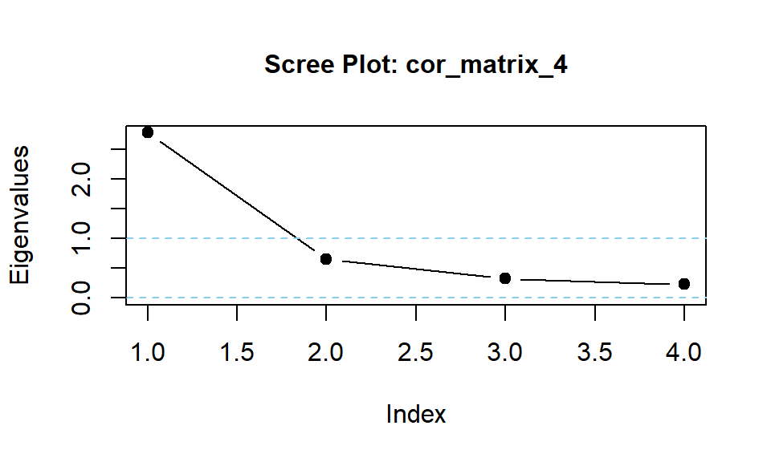

```
#> cor_matrix_4  is positive-definite
#> [1] 2.7842025 0.6581071 0.3291732 0.2285172
```

```r
## using helper function eigenvalues()

eigenvalues(cor_matrix_4, 1)
```

#### twelve variables, alpha = 0.90, variance = 1

```r
## define parameters
items <- 12
alpha <- 0.90
variance <- 1.0

## apply makeCorrAlpha() function
set.seed(42)

cor_matrix_12 <- makeCorrAlpha(items = items, alpha = alpha, variance = variance)
```

[output not shown]

###### -

*makeCorrAlpha()* produced the following correlation matrix (to two decimal places):

```
#>        [,1]  [,2]  [,3]  [,4]  [,5]  [,6]  [,7]  [,8]  [,9] [,10] [,11] [,12]
#>  [1,]  1.00 -0.51 -0.67 -0.32 -0.30 -0.29 -0.27 -0.14 -0.07 -0.04 -0.03  0.00
#>  [2,] -0.51  1.00  0.06  0.31  0.43  0.26  0.28  0.20  0.26  0.06  0.25  0.34
#>  [3,] -0.67  0.06  1.00  0.61  0.36  0.62  0.57  0.47  0.45  0.46  0.47  0.33
#>  [4,] -0.32  0.31  0.61  1.00  0.48  0.50  0.60  0.36  0.39  0.53  0.64  0.59
#>  [5,] -0.30  0.43  0.36  0.48  1.00  0.42  0.56  0.62  0.62  0.62  0.56  0.63
#>  [6,] -0.29  0.26  0.62  0.50  0.42  1.00  0.81  0.66  0.70  0.70  0.70  0.70
#>  [7,] -0.27  0.28  0.57  0.60  0.56  0.81  1.00  0.57  0.71  0.72  0.72  0.73
#>  [8,] -0.14  0.20  0.47  0.36  0.62  0.66  0.57  1.00  0.71  0.79  0.79  0.78
#>  [9,] -0.07  0.26  0.45  0.39  0.62  0.70  0.71  0.71  1.00  0.80  0.83  0.84
#> [10,] -0.04  0.06  0.46  0.53  0.62  0.70  0.72  0.79  0.80  1.00  0.88  0.89
#> [11,] -0.03  0.25  0.47  0.64  0.56  0.70  0.72  0.79  0.83  0.88  1.00  0.97
#> [12,]  0.00  0.34  0.33  0.59  0.63  0.70  0.73  0.78  0.84  0.89  0.97  1.00
```

##### test output

```r
## calculate Cronbach's Alpha
alpha(cor_matrix_12)
```

```
#> [1] 0.9000045
```

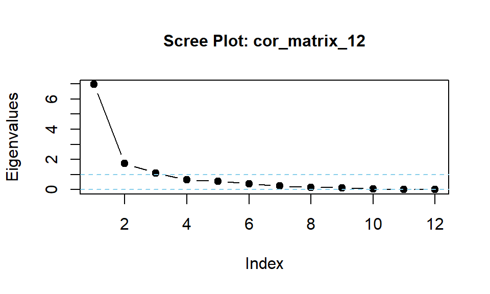

```
#> cor_matrix_12  is positive-definite
#>  [1] 6.964 1.743 1.087 0.658 0.567 0.377 0.254 0.159 0.127 0.051 0.014 0.001
```

```r
## calculate eigenvalues of the correlation matrix
eigenvalues(cor_matrix_12, 1) |> round(3)
```

## Generate a correlation matrix from factor loadings

### makeCorrLoadings

*makeCorrLoadings()* generates a correlation matrix from factor loadings and factor correlations as might be seen in *Exploratory Factor Analysis* (**EFA**) or a *Structural Equation Model* (**SEM**).

#### makeCorrLoadings() usage

```
  makeCorrLoadings(loadings, factorCor = NULL, uniquenesses = NULL, nearPD = FALSE)
```

##### makeCorrLoadings() arguments

- *loadings*: ‘k’ (items) by ‘f’ (factors) matrix of *standardised* factor loadings. Item names and Factor names can be taken from the row_names (items) and the column_names (factors), if present.
- *factorCor*: ‘f’ x ‘f’ factor correlation matrix. If not present, then we assume that the factors are uncorrelated (orthogonal), which is rare in practice, and the function applies an identity matrix for *factor_cor*.
- *uniquenesses*: length ‘k’ vector of uniquenesses. If NULL, the default, compute from the calculated communalities.
- *nearPD*: (logical) If TRUE, then the function calls the *nearPD* function from the **Matrix** package to transform the resulting correlation matrix onto the nearest Positive Definite matrix. Obviously, this only applies if the resulting correlation matrix is not positive definite. (It should never be needed.)

##### Note

“Censored” loadings (for example, where loadings less than some small value (often ‘0.30’), are removed for ease-of-communication) tend to severely reduce the accuracy of the `makeCorrLoadings()` function. For a detailed demonstration, see the vignette file, **makeCorrLoadings_Validate**.

### makeCorrLoadings() examples

#### Typical application from published EFA results

##### define parameters

```r
## Example loadings

factorLoadings <- matrix(
  c(
    0.05, 0.20, 0.70,
    0.10, 0.05, 0.80,
    0.05, 0.15, 0.85,
    0.20, 0.85, 0.15,
    0.05, 0.85, 0.10,
    0.10, 0.90, 0.05,
    0.90, 0.15, 0.05,
    0.80, 0.10, 0.10
  ),
  nrow = 8, ncol = 3, byrow = TRUE
)

## row and column names

rownames(factorLoadings) <- c("Q1", "Q2", "Q3", "Q4", "Q5", "Q6", "Q7", "Q8")
colnames(factorLoadings) <- c("Factor1", "Factor2", "Factor3")

## Factor correlation matrix**

factorCor <- matrix(
  c(
    1.0,  0.5, 0.4,
    0.5,  1.0, 0.3,
    0.4,  0.3, 1.0
  ),
  nrow = 3, byrow = TRUE
)
```

##### Apply the function

```r
## apply makeCorrLoadings() function
itemCorrelations <- makeCorrLoadings(factorLoadings, factorCor)

## derived correlation matrix to two decimal places
round(itemCorrelations, 2)
```

```
#>      Q1   Q2   Q3   Q4   Q5   Q6   Q7   Q8
#> Q1 1.00 0.62 0.67 0.48 0.42 0.42 0.43 0.41
#> Q2 0.62 1.00 0.72 0.43 0.36 0.36 0.44 0.42
#> Q3 0.67 0.72 1.00 0.50 0.43 0.43 0.46 0.45
#> Q4 0.48 0.43 0.50 1.00 0.79 0.83 0.65 0.58
#> Q5 0.42 0.36 0.43 0.79 1.00 0.80 0.54 0.48
#> Q6 0.42 0.36 0.43 0.83 0.80 1.00 0.59 0.52
#> Q7 0.43 0.44 0.46 0.65 0.54 0.59 1.00 0.78
#> Q8 0.41 0.42 0.45 0.58 0.48 0.52 0.78 1.00
```

##### Test makeCorrLoadings() output

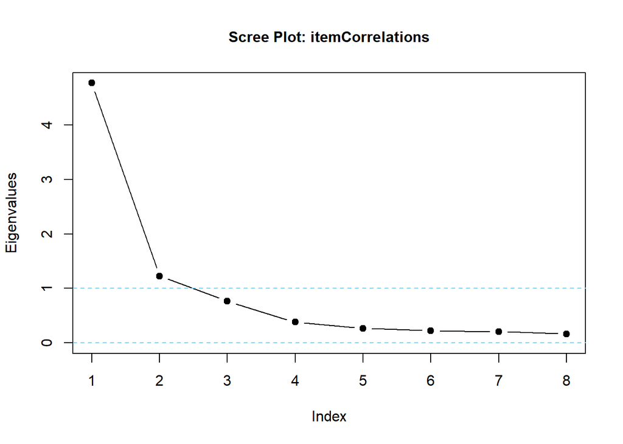

```
#> itemCorrelations  is positive-definite
#> [1] 4.7679427 1.2254239 0.7641967 0.3799863 0.2668158 0.2237851 0.2073574
#> [8] 0.1644922
```

```r
## correlated factors mean that eigenvalues should suggest two or three factors
eigenvalues(cormatrix = itemCorrelations, scree = TRUE)
```

##### Assuming orthogonal factors

```r
## orthogonal factors are assumed when factor correlation matrix is not included
orthogonalItemCors <- makeCorrLoadings(factorLoadings)

## derived correlation matrix to two decimal places
round(orthogonalItemCors, 2)
```

```
#>      Q1   Q2   Q3   Q4   Q5   Q6   Q7   Q8
#> Q1 1.00 0.58 0.63 0.29 0.24 0.22 0.11 0.13
#> Q2 0.58 1.00 0.69 0.18 0.13 0.10 0.14 0.17
#> Q3 0.63 0.69 1.00 0.26 0.22 0.18 0.11 0.14
#> Q4 0.29 0.18 0.26 1.00 0.75 0.79 0.32 0.26
#> Q5 0.24 0.13 0.22 0.75 1.00 0.78 0.18 0.14
#> Q6 0.22 0.10 0.18 0.79 0.78 1.00 0.23 0.18
#> Q7 0.11 0.14 0.11 0.32 0.18 0.23 1.00 0.74
#> Q8 0.13 0.17 0.14 0.26 0.14 0.18 0.74 1.00
```

##### Test orthogonal output

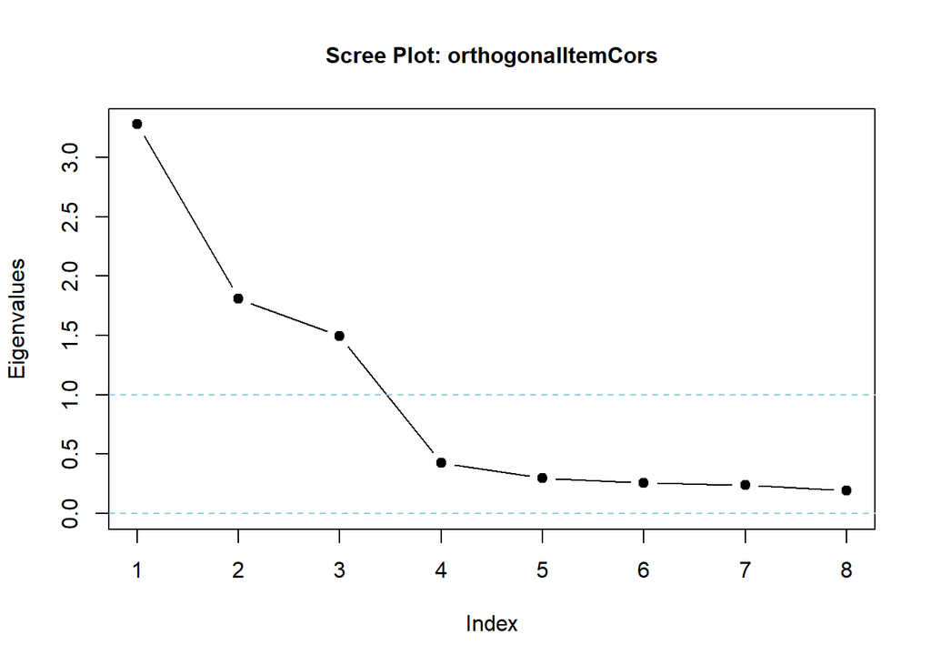

```
#> orthogonalItemCors  is positive-definite
#> [1] 3.2769426 1.8091128 1.4966064 0.4244753 0.2966222 0.2605233 0.2402622
#> [8] 0.1954553
```

```r
## eigenvalues should suggest exactly  three factors
eigenvalues(cormatrix = orthogonalItemCors, scree = TRUE)
```

## Generate a dataframe of rating scales from a correlation matrix and predefined moments

### makeItems()

*makeItems()* generates a dataframe of random discrete values from a *scaled Beta distribution* so the data replicate a rating scale, and are correlated close to a predefined correlation matrix.

Generally, means, standard deviations, and correlations are correct to two decimal places.

*makeItems()* is a wrapper function for

- *lfast()*, which takes repeated samples selecting a vector that best fits the desired moments, and
- *lcor()*, which rearranges values in each column of the dataframe so they closely match the desired correlation matrix.

To create the desired dataframe, the user must define the following parameters:

- *n*: number of observations
- *dfMeans*: a vector of length ‘k’ of desired means of each variable
- *dfSds*: a vector of length ‘k’ of desired standard deviations of each variable
- *lowerbound*: a vector of length ‘k’ of values for the lower bound of each variable (For example, ‘1’ for a 1-5 rating scale)
- *upperbound*: a vector of length ‘k’ of values for the upper bound of each variable (For example, ‘5’ for a 1-5 rating scale)
- *cormatrix*: a target correlation matrix with ‘k’ rows and ‘k’ columns.

### *makeItems()* examples

```r
## define parameters
n <- 128
dfMeans <- c(2.5, 3.0, 3.0, 3.5)
dfSds <- c(1.0, 1.0, 1.5, 0.75)
lowerbound <- rep(1, 4)
upperbound <- rep(5, 4)

corMat <- matrix(
  c(
    1.00, 0.25, 0.35, 0.45,
    0.25, 1.00, 0.70, 0.75,
    0.35, 0.70, 1.00, 0.85,
    0.45, 0.75, 0.85, 1.00
  ),
  nrow = 4, ncol = 4
)

## apply makeItems() function
df <- makeItems(
  n = n,
  means = dfMeans,
  sds = dfSds,
  lowerbound = lowerbound,
  upperbound = upperbound,
  cormatrix = corMat
)
```

```
#> Variable  1
#> reached maximum of 16384 iterations
#> Variable  2
#> reached maximum of 16384 iterations
#> Variable  3
#> best solution in 2371 iterations
#> Variable  4
#> reached maximum of 16384 iterations
#>
#> Arranging data to match correlations
#>
#> Successfully generated correlated variables
```

```r
## test the function
head(df)
```

```
#>
#> 1 4 3 4 4
#> 2 2 4 5 4
#> 3 2 5 5 5
#> 4 1 3 2 3
#> 5 1 2 2 3
#> 6 3 4 5 4
```

```r
tail(df)
```

```
#>
#> 123 3 2 4 4
#> 124 2 4 5 4
#> 125 3 5 4 4
#> 126 3 3 4 4
#> 127 2 1 1 2
#> 128 4 4 3 4
```

```r
### means should be correct to two decimal places
dfmoments <- data.frame(
  mean = apply(df, 2, mean) |> round(3),
  sd = apply(df, 2, sd) |> round(3)
) |> t()

dfmoments
```

```
#>       [,1]  [,2]  [,3]  [,4]
#> mean 2.500 3.000 3.000 3.500
#> sd   1.004 1.004 1.501 0.753
```

```r
### correlations should be correct to two decimal places
cor(df) |> round(3)
```

```
#>       [,1] [,2]  [,3]  [,4]
#> [1,] 1.000 0.25 0.350 0.448
#> [2,] 0.250 1.00 0.700 0.750
#> [3,] 0.350 0.70 1.000 0.836
#> [4,] 0.448 0.75 0.836 1.000
```

## Generate a dataframe from Cronbach’s Alpha and predefined moments

This is a two-step process:

1. apply *makeCorrAlpha()* to generate a correlation matrix from desired alpha,
2. apply *makeItems()* to generate rating-scale items from the correlation matrix and desired moments

Required parameters are:

- *k*: number items/ columns
- *alpha*: a target Cronbach’s Alpha.
- *n*: number of observations
- *lowerbound*: a vector of length ‘k’ of values for the lower bound of each variable
- *upperbound*: a vector of length ‘k’ of values for the upper bound of each variable
- *means*: a vector of length ‘k’ of desired means of each variable
- *sds*: a vector of length ‘k’ of desired standard deviations of each variable

### Step 1: Generate a correlation matrix

```r
## define parameters
k <- 6
myAlpha <- 0.85

## generate correlation matrix
set.seed(42)
myCorr <- makeCorrAlpha(items = k, alpha = myAlpha)
```

```
#> correlation values consistent with desired alpha in 15193 iterations
#> The correlation matrix is positive definite
```

```r
## display correlation matrix
myCorr |> round(3)
```

```
#>        [,1]   [,2]  [,3]  [,4]  [,5]  [,6]
#> [1,]  1.000 -0.153 0.116 0.430 0.438 0.473
#> [2,] -0.153  1.000 0.480 0.498 0.528 0.585
#> [3,]  0.116  0.480 1.000 0.602 0.625 0.641
#> [4,]  0.430  0.498 0.602 1.000 0.662 0.677
#> [5,]  0.438  0.528 0.625 0.662 1.000 0.684
#> [6,]  0.473  0.585 0.641 0.677 0.684 1.000
```

```r
### checking Cronbach's Alpha
alpha(cormatrix = myCorr)
```

```
#> [1] 0.8500101
```

### Step 2: Generate dataframe

```r
## define parameters
n <- 256
myMeans <- c(2.75, 3.00, 3.00, 3.25, 3.50, 3.5)
mySds <- c(1.00, 0.75, 1.00, 1.00, 1.00, 1.5)
lowerbound <- rep(1, k)
upperbound <- rep(5, k)

## Generate Items
myItems <- makeItems(
  n = n, means = myMeans, sds = mySds,
  lowerbound = lowerbound, upperbound = upperbound,
  cormatrix = myCorr
)
```

[output not shown]

```r
## resulting data frame
head(myItems)
```

```
#>
#> 1 3 3 3 3 4 5
#> 2 2 3 3 3 3 4
#> 3 4 3 4 4 5 5
#> 4 2 5 4 3 5 5
#> 5 2 4 4 4 4 4
#> 6 2 3 3 3 3 3
```

```r
tail(myItems)
```

```
#>
#> 251 3 2 2 3 3 3
#> 252 2 3 2 2 3 2
#> 253 1 3 3 2 2 4
#> 254 4 3 4 4 5 5
#> 255 4 2 3 3 3 4
#> 256 4 3 5 5 5 5
```

```r
## means and standard deviations
myMoments <- data.frame(
  means = apply(myItems, 2, mean) |> round(3),
  sds = apply(myItems, 2, sd) |> round(3)
) |> t()
myMoments
```

```
#>        [,1]  [,2]  [,3]  [,4]  [,5]  [,6]
#> means 2.750 3.000 3.000 3.250 3.500 3.500
#> sds   0.998 0.751 1.002 0.998 0.998 1.498
```

```r
## Cronbach's Alpha of data frame
alpha(NULL, myItems)
```

```
#> [1] 0.8499588
```

#### Summary plots of new data frame

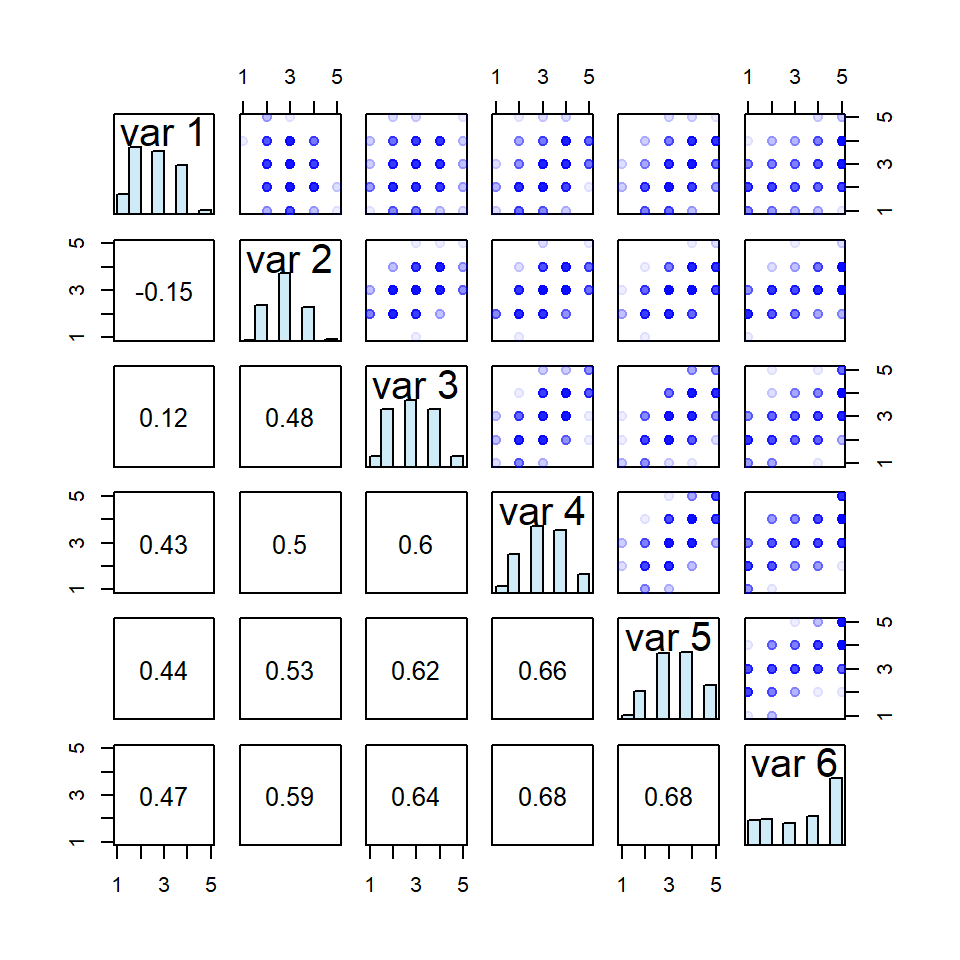

Summary of dataframe from makeItems() function

## Generate a dataframe of rating-scale items from a summated rating scale

### makeItemsScale()

- *makeItemsScale()* generates a dataframe of rating-scale items from a summated rating scale and desired *Cronbach’s Alpha*.

To create the desired dataframe, the user must define the following parameters:

- *scale*: a vector or dataframe of the summated rating scale. Should range from (‘lowerbound’ * ‘items’) to (‘upperbound’ * ‘items’)
- *lowerbound*: lower bound of the scale item (example: ‘1’ in a ‘1’ to ‘5’ rating)
- *upperbound*: upper bound of the scale item (example: ‘5’ in a ‘1’ to ‘5’ rating)
- *items*: k, or number of columns to generate
- *alpha*: desired Cronbach’s Alpha. Default = ‘0.8’
- *variance*: quantile for selecting the combination of items that give summated scores. Must lie between ‘0’ (minimum variance) and ‘1’ (maximum variance). Default = ‘0.5’.

#### *makeItemsScale()* Example:

##### generate a summated scale

```r
## define parameters
n <- 256
mean <- 3.00
sd <- 0.85
lowerbound <- 1
upperbound <- 5
items <- 4

## apply lfast() function
meanScale <- lfast(
  n = n, mean = mean, sd = sd,
  lowerbound = lowerbound, upperbound = upperbound,
  items = items
)
```

```
#> best solution in 900 iterations
```

```r
## sum over all items
summatedScale <- meanScale * items
```

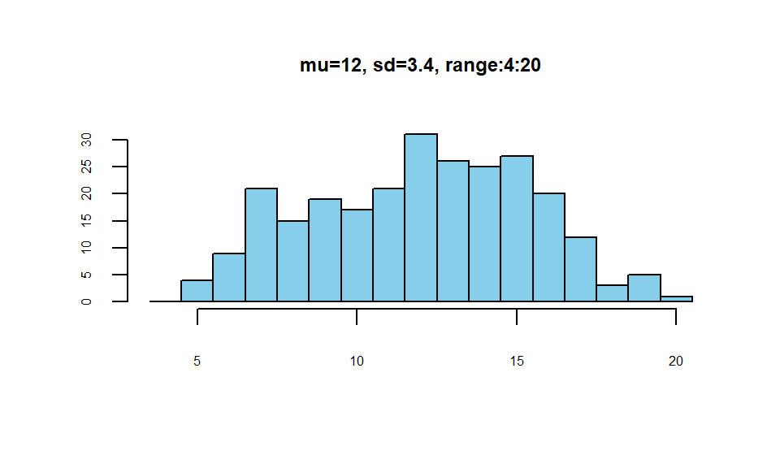

Summated scale distribution

#### create items with *makeItemsScale()*

```r
## apply makeItemsScale() function
newItems_1 <- makeItemsScale(
  scale = summatedScale,
  lowerbound = lowerbound,
  upperbound = upperbound,
  items = items
)
```

```
#> generate 256 rows
#> rearrange 4 values within each of 256 rows
#> Complete!
#> desired Cronbach's alpha = 0.8 (achieved alpha = 0.8004)
```

```r
### First 10 observations and summated scale
head(cbind(newItems_1, summatedScale), 10)
```

```
#>    V1 V2 V3 V4 summatedScale
#> 1   4  1  1  3             9
#> 2   2  2  2  2             8
#> 3   5  1  2  4            12
#> 4   5  4  4  4            17
#> 5   5  2  3  3            13
#> 6   5  5  5  4            19
#> 7   4  1  2  4            11
#> 8   5  4  4  5            18
#> 9   5  3  4  5            17
#> 10  4  1  4  3            12
```

```r
### correlation matrix
cor(newItems_1) |> round(2)
```

```
#>      V1   V2   V3   V4
#> V1 1.00 0.56 0.61 0.51
#> V2 0.56 1.00 0.60 0.33
#> V3 0.61 0.60 1.00 0.39
#> V4 0.51 0.33 0.39 1.00
```

```r
### default Cronbach's alpha = 0.80
alpha(data = newItems_1) |> round(4)
```

```
#> [1] 0.8004
```

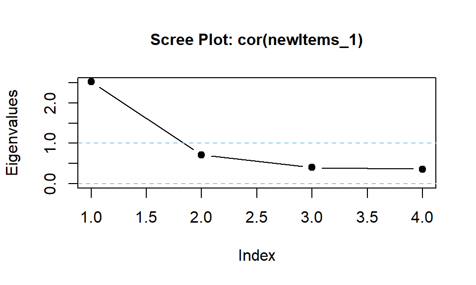

```
#> cor(newItems_1)  is positive-definite
#> [1] 2.517 0.717 0.403 0.364
```

```r
### calculate eigenvalues and print scree plot
eigenvalues(cor(newItems_1), 1) |> round(3)
```